# 💳 Credit Card Customer Behavior & Profit Analysis

##### Created By: Moksh Kapoor

**Tools Used:** Python, Pandas, NumPy, Matplotlib, Seaborn

📊 Aspiring Data Analyst | SQL | Power BI | Excel | Python

```python
import pandas as pd
import numpy as np
import matplotlib.pyplot as plt
%matplotlib inline
import seaborn as sns
import warnings;
warnings.filterwarnings("ignore")
```

```python
cust_acq = pd.read_csv("Customer Acqusition.csv")
Repayment=pd.read_csv("Repayment.csv",)
spend=pd.read_csv("spend.csv")
```

##### EDA - CUST_ACQ

```python
cust_acq.shape
```

```
(100, 8)
```

```python
cust_acq.head()
```

|  | No | Customer | Age | City | Product | Limit | Company | Segment |
| --- | --- | --- | --- | --- | --- | --- | --- | --- |
| 0 | 1 | A1 | 76 | BANGALORE | Gold | 500000.0 | C1 | Self Employed |
| 1 | 2 | A2 | 71 | CALCUTTA | Silver | 100000.0 | C2 | Salaried_MNC |
| 2 | 3 | A3 | 34 | COCHIN | Platimum | 10000.0 | C3 | Salaried_Pvt |
| 3 | 4 | A4 | 47 | BOMBAY | Platimum | 10001.0 | C4 | Govt |
| 4 | 5 | A5 | 56 | BANGALORE | Platimum | 10002.0 | C5 | Normal Salary |

```python
cust_acq.tail()
```

|  | No | Customer | Age | City | Product | Limit | Company | Segment |
| --- | --- | --- | --- | --- | --- | --- | --- | --- |
| 95 | 96 | A96 | 54 | CHENNAI | Silver | 100000.0 | C19 | Salaried_Pvt |
| 96 | 97 | A97 | 58 | TRIVANDRUM | Platimum | 10000.0 | C20 | Govt |
| 97 | 98 | A98 | 51 | CALCUTTA | Platimum | 10001.0 | C21 | Normal Salary |
| 98 | 99 | A99 | 35 | CALCUTTA | Platimum | 10002.0 | C22 | Self Employed |
| 99 | 100 | A100 | 36 | COCHIN | Silver | 100000.0 | C5 | Salaried_MNC |

```python
cust_acq.info()
```

```
<class 'pandas.core.frame.DataFrame'>
RangeIndex: 100 entries, 0 to 99
Data columns (total 8 columns):
 #   Column    Non-Null Count  Dtype
---  ------    --------------  -----
 0   No        100 non-null    int64
 1   Customer  100 non-null    object
 2   Age       100 non-null    int64
 3   City      100 non-null    object
 4   Product   100 non-null    object
 5   Limit     100 non-null    float64
 6   Company   100 non-null    object
 7   Segment   100 non-null    object
dtypes: float64(1), int64(2), object(5)
memory usage: 6.4+ KB
```

```python
cust_acq.duplicated().sum()
```

```
np.int64(0)
```

```python
cust_acq.describe()
```

|  | No | Age | Limit |
| --- | --- | --- | --- |
| count | 100.000000 | 100.000000 | 100.000000 |
| mean | 50.500000 | 46.490000 | 284700.610000 |
| std | 29.011492 | 18.282572 | 218494.967852 |
| min | 1.000000 | 12.000000 | 10000.000000 |
| 25% | 25.750000 | 33.750000 | 100000.000000 |
| 50% | 50.500000 | 46.500000 | 300001.500000 |
| 75% | 75.250000 | 60.250000 | 500000.000000 |
| max | 100.000000 | 79.000000 | 500000.000000 |

```python
cust_acq.isnull().sum()
```

```
No          0
Customer    0
Age         0
City        0
Product     0
Limit       0
Company     0
Segment     0
dtype: int64
```

##### EDA - SPEND

```python
spend.head()
```

|  | Sl No: | Customer | Month | Type | Amount |
| --- | --- | --- | --- | --- | --- |
| 0 | 1 | A1 | 12-Jan-04 | JEWELLERY | 485470.80 |
| 1 | 2 | A1 | 3-Jan-04 | PETRO | 410556.13 |
| 2 | 3 | A1 | 15-Jan-04 | CLOTHES | 23740.46 |
| 3 | 4 | A1 | 25-Jan-04 | FOOD | 484342.47 |
| 4 | 5 | A1 | 17-Jan-05 | CAMERA | 369694.07 |

```python
spend.tail()
```

|  | Sl No: | Customer | Month | Type | Amount |
| --- | --- | --- | --- | --- | --- |
| 1495 | 1496 | A67 | 4-Feb-06 | BUS TICKET | 356872.73 |
| 1496 | 1497 | A68 | 25-Mar-06 | BUS TICKET | 204971.10 |
| 1497 | 1498 | A69 | 31-Mar-06 | BUS TICKET | 50449.44 |
| 1498 | 1499 | A70 | 23-Mar-06 | BUS TICKET | 80593.94 |
| 1499 | 1500 | A71 | 24-Mar-06 | BUS TICKET | 194447.62 |

```python
spend.info()
```

```
<class 'pandas.core.frame.DataFrame'>
RangeIndex: 1500 entries, 0 to 1499
Data columns (total 5 columns):
 #   Column    Non-Null Count  Dtype
---  ------    --------------  -----
 0   Sl No:    1500 non-null   int64
 1   Customer  1500 non-null   object
 2   Month     1500 non-null   object
 3   Type      1500 non-null   object
 4   Amount    1500 non-null   float64
dtypes: float64(1), int64(1), object(3)
memory usage: 58.7+ KB
```

```python
spend.isnull().sum()
```

```
Sl No:      0
Customer    0
Month       0
Type        0
Amount      0
dtype: int64
```

```python
spend.duplicated().sum()
```

```
np.int64(0)
```

```python
spend.describe()
```

|  | Sl No: | Amount |
| --- | --- | --- |
| count | 1500.000000 | 1500.000000 |
| mean | 750.500000 | 243096.049460 |
| std | 433.157015 | 141349.547367 |
| min | 1.000000 | 720.300000 |
| 25% | 375.750000 | 122606.487500 |
| 50% | 750.500000 | 239210.360000 |
| 75% | 1125.250000 | 361617.632500 |
| max | 1500.000000 | 499793.490000 |

##### EDA - REPAYMENT

```python
Repayment.head()
```

|  | SL No: | Customer | Month | Amount | Unnamed: 4 |
| --- | --- | --- | --- | --- | --- |
| 0 | NaN | A1 | 12-Jan-04 | 495414.75 | NaN |
| 1 | 2.0 | A1 | 3-Jan-04 | 245899.02 | NaN |
| 2 | 3.0 | A1 | 15-Jan-04 | 259490.06 | NaN |
| 3 | 4.0 | A1 | 25-Jan-04 | 437555.12 | NaN |
| 4 | 5.0 | A1 | 17-Jan-05 | 165972.88 | NaN |

```python
Repayment.tail()
```

|  | SL No: | Customer | Month | Amount | Unnamed: 4 |
| --- | --- | --- | --- | --- | --- |
| 1518 | NaN | NaN | NaN | NaN | NaN |
| 1519 | NaN | NaN | NaN | NaN | NaN |
| 1520 | NaN | NaN | NaN | NaN | NaN |
| 1521 | NaN | NaN | NaN | NaN | NaN |
| 1522 | NaN | NaN | NaN | NaN | NaN |

```python
Repayment.info()
```

```
<class 'pandas.core.frame.DataFrame'>
RangeIndex: 1523 entries, 0 to 1522
Data columns (total 5 columns):
 #   Column      Non-Null Count  Dtype
---  ------      --------------  -----
 0   SL No:      1499 non-null   float64
 1   Customer    1500 non-null   object
 2   Month       1500 non-null   object
 3   Amount      1500 non-null   float64
 4   Unnamed: 4  0 non-null      float64
dtypes: float64(3), object(2)
memory usage: 59.6+ KB
```

```python
Repayment.isnull().sum()/Repayment.shape[0]*100
```

```
SL No:          1.575837
Customer        1.510177
Month           1.510177
Amount          1.510177
Unnamed: 4    100.000000
dtype: float64
```

```python
Repayment.duplicated().sum()
```

```
np.int64(22)
```

```python
Repayment.describe()
```

|  | SL No: | Amount | Unnamed: 4 |
| --- | --- | --- | --- |
| count | 1499.00000 | 1500.000000 | 0.0 |
| mean | 751.00000 | 247890.054420 | NaN |
| std | 432.86834 | 145290.382733 | NaN |
| min | 2.00000 | 55.860000 | NaN |
| 25% | 376.50000 | 118604.905000 | NaN |
| 50% | 751.00000 | 248008.185000 | NaN |
| 75% | 1125.50000 | 367236.890000 | NaN |
| max | 1500.00000 | 499930.660000 | NaN |

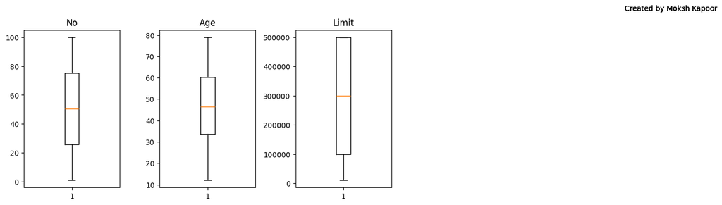

```python
num_cols = cust_acq.select_dtypes(include = ["float","int"])
num_cols
plt.figure(figsize=(13,7))
for i,col in enumerate(num_cols.columns):
    plt.subplot(2,5,i+1)
    plt.boxplot(num_cols[col])
    plt.title(col)
    plt.figtext(1,1,
    "Created by Moksh Kapoor",
    ha="center",
    fontsize=10
)
plt.tight_layout()
plt.show()
```

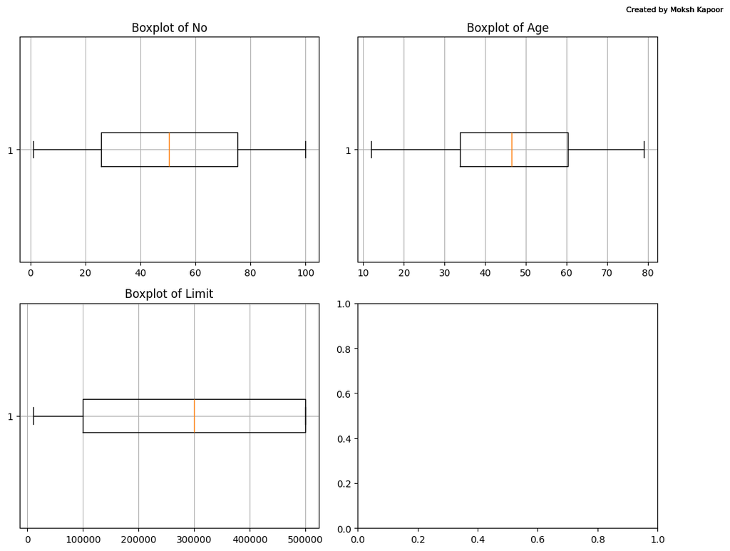

```python
num_cols = cust_acq.select_dtypes(include = ["float","int"])

n = len(num_cols.columns)
per_row_plot = 2

row  = (n+per_row_plot-1)//per_row_plot

fig,axes = plt.subplots(row,per_row_plot, figsize=(5 * per_row_plot, 4 * row))

axes = axes.flatten()

for i, col in enumerate(num_cols.columns):
    axes[i].boxplot(num_cols[col].dropna(),vert=False)
    axes[i].set_title(f'Boxplot of {col}')
    axes[i].grid(True)
    plt.figtext(1,1,
    "Created by Moksh Kapoor",
    ha="center",
    fontsize=8
)
plt.tight_layout()
plt.show()
```

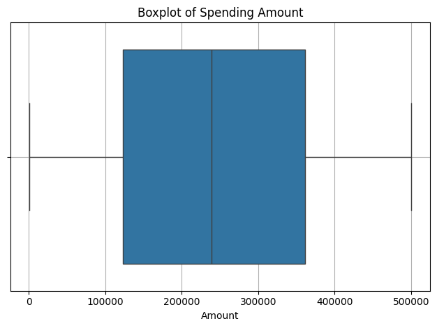

```python
sns.boxplot(x =spend["Amount"] ,vert = False)
plt.title(f'Boxplot of Spending Amount')
plt.grid(True)
plt.tight_layout()
plt.show()
```

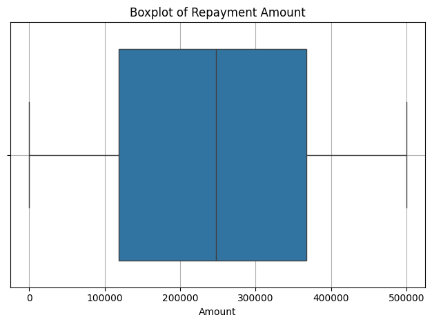

```python
sns.boxplot(x =Repayment["Amount"] ,vert = False)
plt.title(f'Boxplot of Repayment Amount')
plt.grid(True)
plt.tight_layout()
plt.show()
```

#### Data Cleaning

```python
cust_acq.drop("No",axis =1,inplace = True)
```

```python
spend.drop("Sl No:",axis =1,inplace = True)
```

```python
spend["Month"] = pd.to_datetime(spend["Month"],format = "%d-%b-%y")
```

```python
Repayment.drop(["SL No:","Unnamed: 4"],axis = 1,inplace = True)
```

```python
Repayment[Repayment.isnull().any(axis = 1)].size
```

```
69
```

```python
Repayment.dropna(axis=0,inplace=True)
```

```python
Repayment["Month"] = pd.to_datetime(Repayment["Month"],format = "%d-%b-%y")
```

```python
cust_acq.isnull().sum()
```

```
Customer    0
Age         0
City        0
Product     0
Limit       0
Company     0
Segment     0
dtype: int64
```

```python
spend.isnull().sum()
```

```
Customer    0
Month       0
Type        0
Amount      0
dtype: int64
```

```python
Repayment.isnull().sum()
```

```
Customer    0
Month       0
Amount      0
dtype: int64
```

### Data Analysis

1. In the above dataset, a. In case age is less than 18, replace it with mean of age values.

```python
cust_acq.loc[(cust_acq["Age"]<18),"Age"]=cust_acq["Age"].mean()
```

b. In case spend amount is more than the limit, replace it with 50% of that customer’s limit. (customer’s limit provided in acquisition table is the per transaction limit on his card)

```python
Customer_Spend_Transaction=pd.merge(left=cust_acq,right=spend,on='Customer')
Customer_Spend_Transaction
```

|  | Customer | Age | City | Product | Limit | Company | Segment | Month | Type | Amount |
| --- | --- | --- | --- | --- | --- | --- | --- | --- | --- | --- |
| 0 | A1 | 76.0 | BANGALORE | Gold | 500000.0 | C1 | Self Employed | 2004-01-12 | JEWELLERY | 485470.80 |
| 1 | A1 | 76.0 | BANGALORE | Gold | 500000.0 | C1 | Self Employed | 2004-01-03 | PETRO | 410556.13 |
| 2 | A1 | 76.0 | BANGALORE | Gold | 500000.0 | C1 | Self Employed | 2004-01-15 | CLOTHES | 23740.46 |
| 3 | A1 | 76.0 | BANGALORE | Gold | 500000.0 | C1 | Self Employed | 2004-01-25 | FOOD | 484342.47 |
| 4 | A1 | 76.0 | BANGALORE | Gold | 500000.0 | C1 | Self Employed | 2005-01-17 | CAMERA | 369694.07 |
| ... | ... | ... | ... | ... | ... | ... | ... | ... | ... | ... |
| 1495 | A96 | 54.0 | CHENNAI | Silver | 100000.0 | C19 | Salaried_Pvt | 2004-01-25 | BIKE | 54729.66 |
| 1496 | A97 | 58.0 | TRIVANDRUM | Platimum | 10000.0 | C20 | Govt | 2004-01-12 | AUTO | 139018.26 |
| 1497 | A98 | 51.0 | CALCUTTA | Platimum | 10001.0 | C21 | Normal Salary | 2004-01-03 | SHOPPING | 284521.06 |
| 1498 | A99 | 35.0 | CALCUTTA | Platimum | 10002.0 | C22 | Self Employed | 2004-01-15 | AIR TICKET | 90184.22 |
| 1499 | A100 | 36.0 | COCHIN | Silver | 100000.0 | C5 | Salaried_MNC | 2004-01-25 | BUS TICKET | 224786.88 |

1500 rows × 10 columns

```python
Customer_Spend_Transaction['Amount']=np.where(Customer_Spend_Transaction['Amount']>Customer_Spend_Transaction['Limit'],
Customer_Spend_Transaction['Limit']*0.5,Customer_Spend_Transaction['Amount'])
```

```python
Customer_Spend_Transaction
```

|  | Customer | Age | City | Product | Limit | Company | Segment | Month | Type | Amount |
| --- | --- | --- | --- | --- | --- | --- | --- | --- | --- | --- |
| 0 | A1 | 76.0 | BANGALORE | Gold | 500000.0 | C1 | Self Employed | 2004-01-12 | JEWELLERY | 485470.80 |
| 1 | A1 | 76.0 | BANGALORE | Gold | 500000.0 | C1 | Self Employed | 2004-01-03 | PETRO | 410556.13 |
| 2 | A1 | 76.0 | BANGALORE | Gold | 500000.0 | C1 | Self Employed | 2004-01-15 | CLOTHES | 23740.46 |
| 3 | A1 | 76.0 | BANGALORE | Gold | 500000.0 | C1 | Self Employed | 2004-01-25 | FOOD | 484342.47 |
| 4 | A1 | 76.0 | BANGALORE | Gold | 500000.0 | C1 | Self Employed | 2005-01-17 | CAMERA | 369694.07 |
| ... | ... | ... | ... | ... | ... | ... | ... | ... | ... | ... |
| 1495 | A96 | 54.0 | CHENNAI | Silver | 100000.0 | C19 | Salaried_Pvt | 2004-01-25 | BIKE | 54729.66 |
| 1496 | A97 | 58.0 | TRIVANDRUM | Platimum | 10000.0 | C20 | Govt | 2004-01-12 | AUTO | 5000.00 |
| 1497 | A98 | 51.0 | CALCUTTA | Platimum | 10001.0 | C21 | Normal Salary | 2004-01-03 | SHOPPING | 5000.50 |
| 1498 | A99 | 35.0 | CALCUTTA | Platimum | 10002.0 | C22 | Self Employed | 2004-01-15 | AIR TICKET | 5001.00 |
| 1499 | A100 | 36.0 | COCHIN | Silver | 100000.0 | C5 | Salaried_MNC | 2004-01-25 | BUS TICKET | 50000.00 |

1500 rows × 10 columns

c. Incase the repayment amount is more than the limit, replace the repayment with the limit.

```python
merged_data = pd.merge(Customer_Spend_Transaction,Repayment,on='Customer',suffixes=("_spend","_repayment"),how = "inner")
merged_data
```

|  | Customer | Age | City | Product | Limit | Company | Segment | Month_spend | Type | Amount_spend | Month_repayment | Amount_repayment |
| --- | --- | --- | --- | --- | --- | --- | --- | --- | --- | --- | --- | --- |
| 0 | A1 | 76.0 | BANGALORE | Gold | 500000.0 | C1 | Self Employed | 2004-01-12 | JEWELLERY | 485470.80 | 2004-01-12 | 495414.75 |
| 1 | A1 | 76.0 | BANGALORE | Gold | 500000.0 | C1 | Self Employed | 2004-01-12 | JEWELLERY | 485470.80 | 2004-01-03 | 245899.02 |
| 2 | A1 | 76.0 | BANGALORE | Gold | 500000.0 | C1 | Self Employed | 2004-01-12 | JEWELLERY | 485470.80 | 2004-01-15 | 259490.06 |
| 3 | A1 | 76.0 | BANGALORE | Gold | 500000.0 | C1 | Self Employed | 2004-01-12 | JEWELLERY | 485470.80 | 2004-01-25 | 437555.12 |
| 4 | A1 | 76.0 | BANGALORE | Gold | 500000.0 | C1 | Self Employed | 2004-01-12 | JEWELLERY | 485470.80 | 2005-01-17 | 165972.88 |
| ... | ... | ... | ... | ... | ... | ... | ... | ... | ... | ... | ... | ... |
| 37279 | A96 | 54.0 | CHENNAI | Silver | 100000.0 | C19 | Salaried_Pvt | 2004-01-25 | BIKE | 54729.66 | 2004-01-25 | 310992.30 |
| 37280 | A97 | 58.0 | TRIVANDRUM | Platimum | 10000.0 | C20 | Govt | 2004-01-12 | AUTO | 5000.00 | 2004-01-12 | 121874.90 |
| 37281 | A98 | 51.0 | CALCUTTA | Platimum | 10001.0 | C21 | Normal Salary | 2004-01-03 | SHOPPING | 5000.50 | 2004-01-03 | 337815.57 |
| 37282 | A99 | 35.0 | CALCUTTA | Platimum | 10002.0 | C22 | Self Employed | 2004-01-15 | AIR TICKET | 5001.00 | 2004-01-15 | 25682.73 |
| 37283 | A100 | 36.0 | COCHIN | Silver | 100000.0 | C5 | Salaried_MNC | 2004-01-25 | BUS TICKET | 50000.00 | 2004-01-25 | 69551.19 |

37284 rows × 12 columns

```python
merged_data.loc[merged_data["Amount_repayment"]>merged_data["Limit"],"Amount_repayment"] = merged_data[merged_data["Amount_repayment"]>merged_data["Limit"]]["Limit"]
```

```python
merged_data
```

|  | Customer | Age | City | Product | Limit | Company | Segment | Month_spend | Type | Amount_spend | Month_repayment | Amount_repayment |
| --- | --- | --- | --- | --- | --- | --- | --- | --- | --- | --- | --- | --- |
| 0 | A1 | 76.0 | BANGALORE | Gold | 500000.0 | C1 | Self Employed | 2004-01-12 | JEWELLERY | 485470.80 | 2004-01-12 | 495414.75 |
| 1 | A1 | 76.0 | BANGALORE | Gold | 500000.0 | C1 | Self Employed | 2004-01-12 | JEWELLERY | 485470.80 | 2004-01-03 | 245899.02 |
| 2 | A1 | 76.0 | BANGALORE | Gold | 500000.0 | C1 | Self Employed | 2004-01-12 | JEWELLERY | 485470.80 | 2004-01-15 | 259490.06 |
| 3 | A1 | 76.0 | BANGALORE | Gold | 500000.0 | C1 | Self Employed | 2004-01-12 | JEWELLERY | 485470.80 | 2004-01-25 | 437555.12 |
| 4 | A1 | 76.0 | BANGALORE | Gold | 500000.0 | C1 | Self Employed | 2004-01-12 | JEWELLERY | 485470.80 | 2005-01-17 | 165972.88 |
| ... | ... | ... | ... | ... | ... | ... | ... | ... | ... | ... | ... | ... |
| 37279 | A96 | 54.0 | CHENNAI | Silver | 100000.0 | C19 | Salaried_Pvt | 2004-01-25 | BIKE | 54729.66 | 2004-01-25 | 100000.00 |
| 37280 | A97 | 58.0 | TRIVANDRUM | Platimum | 10000.0 | C20 | Govt | 2004-01-12 | AUTO | 5000.00 | 2004-01-12 | 10000.00 |
| 37281 | A98 | 51.0 | CALCUTTA | Platimum | 10001.0 | C21 | Normal Salary | 2004-01-03 | SHOPPING | 5000.50 | 2004-01-03 | 10001.00 |
| 37282 | A99 | 35.0 | CALCUTTA | Platimum | 10002.0 | C22 | Self Employed | 2004-01-15 | AIR TICKET | 5001.00 | 2004-01-15 | 10002.00 |
| 37283 | A100 | 36.0 | COCHIN | Silver | 100000.0 | C5 | Salaried_MNC | 2004-01-25 | BUS TICKET | 50000.00 | 2004-01-25 | 69551.19 |

37284 rows × 12 columns

**KPI**

```python
Total_Customers  =  merged_data["Customer"].nunique()
print("Total_Customers",Total_Customers)

avg_age = merged_data['Age'].mean()
print("avg_age",avg_age)

total_categories = merged_data['Type'].nunique()
print("total_categories",total_categories)

total_spend = int(merged_data['Amount_spend'].sum())
print("total_spend",total_spend)

total_repayment = int(merged_data['Amount_repayment'].sum())
print("total_repayment",total_repayment)

total_profit = total_repayment - total_spend
print("total_profit",total_profit)

top_city = merged_data.groupby('City')['Amount_spend'].sum().idxmax()
print("top_city",top_city)

top_segment = merged_data.groupby('Segment')['Amount_spend'].sum().idxmax()
print("top_segment",top_segment)

top_category = merged_data.groupby('Type')['Amount_spend'].sum().idxmax()
print("top_category",top_category)

avg_monthly_spend = int(merged_data.groupby(merged_data["Month_spend"].dt.to_period("M"))["Amount_spend"].sum().mean())
print("avg_monthly_spend",avg_monthly_spend)

avg_monthly_repayment = int(merged_data.groupby(merged_data['Month_repayment'].dt.to_period('M'))['Amount_repayment'].sum().mean())
print("avg_monthly_repayment",avg_monthly_repayment)
```

```
Total_Customers 100
avg_age 44.91389335908165
total_categories 15
total_spend 5747987637
total_repayment 6345320120
total_profit 597332483
top_city COCHIN
top_segment Salaried_Pvt
top_category CAMERA
avg_monthly_spend 191599587
avg_monthly_repayment 211510670
```

2. From the above dataset create the following summaries: a. How many distinct customers exist?

```python
merged_data["Customer"].nunique()
```

```
100
```

b. How many distinct categories exist?

```python
merged_data["Type"].nunique()
```

```
15
```

c. What is the average monthly spend by customers?

```python
monthly_spend = merged_data.groupby(
    merged_data["Month_spend"].dt.to_period("M")
)["Amount_spend"].sum()

month_order = ["January","February","March","April","May","June","July","August","September","October","Novemeber","December"]
monthly_spend.index = monthly_spend.index.to_timestamp()
avg_monthly_spend = monthly_spend.groupby(monthly_spend.index.month_name()).mean()
avg_monthly_spend = avg_monthly_spend.reindex(month_order).reset_index()
avg_monthly_spend.rename(
    columns={"Month_spend": "Month", "Amount_spend": "Avg_Amt"},inplace=True)
avg_monthly_spend
```

|  | Month | Avg_Amt |
| --- | --- | --- |
| 0 | January | 4.463608e+08 |
| 1 | February | 3.085696e+08 |
| 2 | March | 3.804942e+08 |
| 3 | April | 1.765223e+08 |
| 4 | May | 2.845585e+08 |
| 5 | June | 1.460196e+08 |
| 6 | July | 9.909898e+07 |
| 7 | August | 9.436897e+07 |
| 8 | September | 5.544558e+07 |
| 9 | October | 5.070407e+07 |
| 10 | Novemeber | NaN |
| 11 | December | 3.809243e+07 |

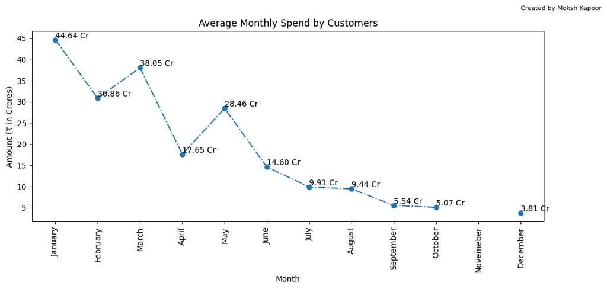

```python
plt.figure(figsize=(10,5))

amount_cr = avg_monthly_spend['Avg_Amt'] / 1e7

plt.plot(avg_monthly_spend['Month'], amount_cr,linestyle="dashdot", marker="o")

for i, v in enumerate(amount_cr):
    plt.text(i, v, f"{v:.2f} Cr", ha="left", va="bottom")

plt.title("Average Monthly Spend by Customers")
plt.xlabel("Month")
plt.ylabel("Amount (₹ in Crores)")
plt.figtext(1,1,
    "Created by Moksh Kapoor",
    ha="center",
    fontsize=8
)
plt.xticks(rotation=90)
plt.tight_layout()

plt.show()
```

d. What is the average monthly repayment by customers?

```python
monthly_repayment = merged_data.groupby(
    merged_data["Month_repayment"].dt.to_period("M")
)["Amount_repayment"].sum()

monthly_repayment.index = monthly_repayment.index.to_timestamp()
avg_monthly_repayment = monthly_repayment.groupby(monthly_repayment.index.month_name()).mean()
avg_monthly_repayment = avg_monthly_repayment.reindex(month_order).reset_index()
avg_monthly_repayment.rename(
    columns={"Month_repayment": "Month", "Amount_repayment": "Avg_Repayment_Amt"},inplace=True)
avg_monthly_repayment
```

|  | Month | Avg_Repayment_Amt |
| --- | --- | --- |
| 0 | January | 4.502518e+08 |
| 1 | February | 3.115035e+08 |
| 2 | March | 4.037907e+08 |
| 3 | April | 2.205293e+08 |
| 4 | May | 4.380174e+08 |
| 5 | June | 7.696641e+07 |
| 6 | July | 1.090864e+08 |
| 7 | August | 1.045775e+08 |
| 8 | September | 4.695531e+07 |
| 9 | October | 5.285584e+07 |
| 10 | Novemeber | NaN |
| 11 | December | 5.814008e+07 |

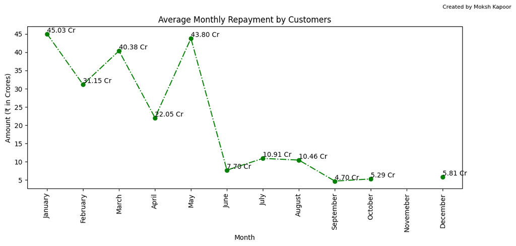

```python
plt.figure(figsize=(10,5))

amount_cr = avg_monthly_repayment['Avg_Repayment_Amt'] / 1e7

plt.plot(avg_monthly_repayment['Month'], amount_cr,linestyle="dashdot", marker="o" , color = "Green")

for i, v in enumerate(amount_cr):
    plt.text(i, v, f"{v:.2f} Cr", ha="left", va="bottom")

plt.title("Average Monthly Repayment by Customers")
plt.xlabel("Month")
plt.ylabel("Amount (₹ in Crores)")
plt.figtext(1,1,
    "Created by Moksh Kapoor",
    ha="center",
    fontsize=8
)
plt.xticks(rotation=90)
plt.tight_layout()

plt.show()
```

e. If the monthly rate of interest is 2.9%, what is the profit for the bank for each month? (Profit is defined as interest earned on Monthly Profit. Monthly Profit = Monthly repayment – Monthly spend. Interest is earned only on positive profits and not on negative amount

```python
monthly = merged_data.groupby(merged_data['Month_spend'].dt.to_period('M')).agg({'Amount_spend':'sum','Amount_repayment': 'sum'})
Monthly_Profit = monthly['Amount_repayment'] - monthly['Amount_spend']
monthly['Profit'] = np.where(
    Monthly_Profit > 0,
    Monthly_Profit * 0.029,
    0)
pd.options.display.float_format = '{:.2f}'.format
monthly.loc[:,["Profit"]]
```

| Month_spend | Profit |
| --- | --- |
| 2004-01 | 2754331.53 |
| 2004-02 | 597940.12 |
| 2004-03 | 114536.08 |
| 2004-04 | 527777.02 |
| 2004-05 | 412641.93 |
| 2004-09 | 0.00 |
| 2004-11 | 574425.88 |
| 2005-01 | 0.00 |
| 2005-02 | 3402288.79 |
| 2005-04 | 253505.99 |
| 2005-05 | 1534326.96 |
| 2005-06 | 0.00 |
| 2005-07 | 348574.18 |
| 2005-08 | 238433.40 |
| 2005-09 | 237137.00 |
| 2005-10 | 452248.37 |
| 2005-11 | 0.00 |
| 2005-12 | 778989.45 |
| 2006-01 | 198872.79 |
| 2006-02 | 0.00 |
| 2006-03 | 3003460.68 |
| 2006-04 | 1352025.21 |
| 2006-05 | 370626.81 |
| 2006-06 | 146092.57 |
| 2006-07 | 0.00 |
| 2006-08 | 219413.31 |
| 2006-09 | 621621.93 |
| 2006-10 | 302080.08 |
| 2006-11 | 789151.38 |
| 2006-12 | 241782.92 |

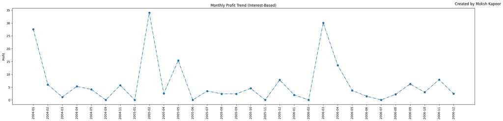

```python
monthly.index = monthly.index.astype(str)
amount_cr = monthly['Profit'] / 1e5
plt.figure(figsize=(22,5))
plt.plot(monthly.index, amount_cr, marker='o' , linestyle = "-.")
plt.tight_layout()
plt.xticks(rotation=90)
plt.ylabel("Profit")
plt.figtext(1,1,
    "Created by Moksh Kapoor",
    ha="center",
    fontsize=12
)
plt.title("Monthly Profit Trend (Interest-Based)")
plt.show()
```

f. What are the top 5 product types?

```python
top_5 = merged_data.groupby(merged_data["Type"])["Amount_spend"].sum().reset_index().sort_values('Amount_spend',ascending=False)
top_5 =top_5.rename(columns = {"Type":"Product_Types","Amount_spend":"Spending_Amt"})
top_5.head(5)
```

|  | Product_Types | Spending_Amt |
| --- | --- | --- |
| 4 | CAMERA | 751701147.41 |
| 10 | PETRO | 707154852.84 |
| 7 | FOOD | 547883478.50 |
| 0 | AIR TICKET | 540117988.32 |
| 14 | TRAIN TICKET | 534423947.80 |

[figure not shown]

```python
Top_type = top_5.head(5)
colors = ["green", "blue", "lightblue", "orange", "purple"]
Top_type.plot(x="Product_Types", y="Spending_Amt", kind="bar" , color= colors)
for i,v in enumerate(Top_type["Spending_Amt"]):
    plt.text(i,v,f"{str(round(v/1e7,2))} cr" , ha = "center" , va = "bottom")
plt.tight_layout()
plt.xticks(rotation=90)
plt.xlabel("Product Types")
plt.ylabel("Spending Amt")
plt.figtext(1,1,
    "Created by Moksh Kapoor",
    ha="center",
    fontsize=8
)
plt.title("Monthly Profit Trend (Interest-Based)")
plt.legend().remove()
plt.show()
```

g. Which city is having maximum spend?

```python
city_wise_distribution = merged_data.groupby(merged_data["City"])["Amount_spend"].sum().reset_index().sort_values('Amount_spend',ascending=False)
city_wise_distribution["Amount_spend"] = city_wise_distribution["Amount_spend"].apply(lambda x:round(x/1e7))
city_wise_distribution.rename(columns={"Amount_spend": "Spend_cr"},inplace=True)
city_wise_distribution.reset_index(drop=True)
```

|  | City | Spend_cr |
| --- | --- | --- |
| 0 | COCHIN | 118 |
| 1 | CALCUTTA | 111 |
| 2 | BANGALORE | 108 |
| 3 | BOMBAY | 76 |
| 4 | CHENNAI | 57 |
| 5 | TRIVANDRUM | 44 |
| 6 | PATNA | 34 |
| 7 | DELHI | 26 |

h. Which age group is spending more money?

```python
merged_data["Age_Group"] = pd.cut(merged_data["Age"],bins = [0,25,65,100],labels = ["Youth", "Adult","Senior"],right=False)
```

```python
age_group =merged_data.groupby(merged_data["Age_Group"])["Amount_spend"].sum().reset_index().sort_values('Amount_spend',ascending=False)
age_group["Amount_spend"] = age_group["Amount_spend"].apply(lambda x:int(x/1e7))
age_group.rename(columns={"Amount_spend": "Spend_cr"},inplace=True)
age_group.reset_index(drop=True)
```

|  | Age_Group | Spend_cr |
| --- | --- | --- |
| 0 | Adult | 444 |
| 1 | Senior | 88 |
| 2 | Youth | 41 |

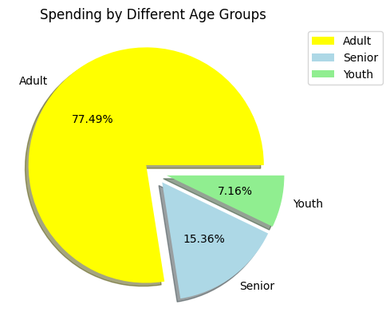

```python
plt.figure(figsize = (5,8))
plt.pie(age_group["Spend_cr"],labels = age_group["Age_Group"],autopct = "%.2f%%",colors  = ["yellow","lightblue","lightgreen"],explode =(0.1,0.1,0.1),shadow =True)
plt.title("Spending by Different Age Groups ")
plt.legend(bbox_to_anchor = (1,1))
plt.tight_layout()
plt.show()
```

i. Who are the top 10 customers in terms of repayment?

```python
top10cust = merged_data.groupby("Customer")["Amount_repayment"].sum().sort_values(ascending  = False).head(10).reset_index()
top10cust["Amount_repayment"]=  top10cust["Amount_repayment"].apply(lambda x:int(x/1e7))
top10cust.rename(columns={"Amount_repayment": "Spend_cr"},inplace=True)
top10cust.set_index("Customer").transpose()
```

| Customer | A61 | A60 | A13 | A43 | A45 | A12 | A14 | A44 | A39 | A42 |
| --- | --- | --- | --- | --- | --- | --- | --- | --- | --- | --- |
| Spend_cr | 40 | 37 | 29 | 26 | 26 | 25 | 24 | 24 | 23 | 23 |

3. Calculate the city wise spend on each product on yearly basis. Also include a graphical representation for the same

```python
City_product_spend = merged_data.groupby([merged_data["Month_spend"].dt.year,"City","Product"])["Amount_spend"].sum().unstack([2])
City_product_spend
```

| Month_spend | Product City | Gold | Platimum | Silver |
| --- | --- | --- | --- | --- |
| 2004 | BANGALORE | 248006886.30 | 29426569.04 | 28450890.41 |
|  | BOMBAY | 187728351.76 | 23440735.60 | 17558937.99 |
|  | CALCUTTA | 206156655.66 | 60838321.30 | 7900114.00 |
|  | CHENNAI | 23616080.00 | 103475012.62 | 4146619.26 |
|  | COCHIN | 186219681.82 | 77046314.76 | 17184164.74 |
|  | DELHI | 78076192.30 | 5103232.02 | 18059029.10 |
|  | PATNA | 41661303.80 | 20035252.80 | 19749592.67 |
|  | TRIVANDRUM | 65207776.68 | 66861976.77 | 3819368.96 |
| 2005 | BANGALORE | 357076946.75 | 22425262.69 | 18538095.66 |
|  | BOMBAY | 248808585.02 | 18337559.42 | 15196573.82 |
|  | CALCUTTA | 285171825.77 | 132089631.50 | 6309944.06 |
|  | CHENNAI | 101005530.66 | 136229986.52 | 6789320.82 |
|  | COCHIN | 335361079.69 | 137271132.91 | 15081595.56 |
|  | DELHI | 47318367.08 | 8894841.48 | 14137723.47 |
|  | PATNA | 83753865.04 | 51898159.26 | 25353891.58 |
|  | TRIVANDRUM | 33490147.95 | 111644742.30 | 5128346.81 |
| 2006 | BANGALORE | 329375735.13 | 17328725.56 | 30685840.02 |
|  | BOMBAY | 203544694.39 | 24291062.70 | 20870001.80 |
|  | CALCUTTA | 299310937.75 | 104977286.68 | 11515401.92 |
|  | CHENNAI | 64093974.49 | 130064754.20 | 5450162.50 |
|  | COCHIN | 271183940.53 | 116126597.60 | 20428705.05 |
|  | DELHI | 68876259.43 | 3182196.96 | 19336599.39 |
|  | PATNA | 61456905.63 | 22610477.70 | 16950090.00 |
|  | TRIVANDRUM | 73864193.49 | 66569516.25 | 8811362.28 |

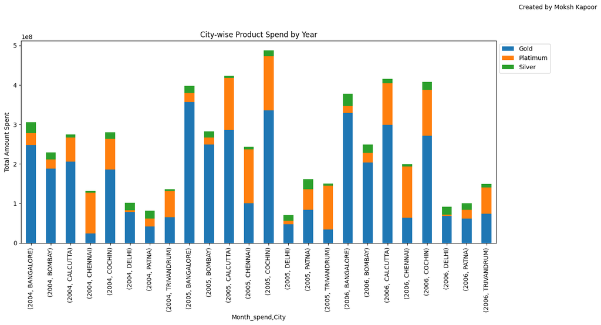

```python
fig, ax = plt.subplots(figsize=(14, 6))

City_product_spend.plot(kind = "bar",stacked =True,ax= ax)
plt.title("City-wise Product Spend by Year")
plt.ylabel("Total Amount Spent")
plt.legend(bbox_to_anchor = (1,1), loc = "upper left")
plt.figtext(1,1,
    "Created by Moksh Kapoor",
    ha="center",
    fontsize=10
)
plt.show()
```

**Insights**

2 Cochin and Calcutta Are Strong Markets  
a) Cochin shows high **Platinum** and **Gold** card spending, especially in **2005** and **2006**.

3 **Delhi** and **Patna** show relatively lower spending across all card types which opens opportunity for company to increase their customer base and profits.

5 Run **Promotional Campaigns for Gold & Platinum customers to increase profits and improve retention in top-performing cities by giving personalized offers, loyalty rewards, and premium experiences.

4. Create graphs for a. Monthly comparison of total spends, city wise

```python
City_Monthly_spend = merged_data.groupby([merged_data["Month_spend"].dt.month,"City"])["Amount_spend"].sum().reset_index()
City_Monthly_spend
```

|  | Month_spend | City | Amount_spend |
| --- | --- | --- | --- |
| 0 | 1 | BANGALORE | 230839627.64 |
| 1 | 1 | BOMBAY | 165719132.84 |
| 2 | 1 | CALCUTTA | 252873938.68 |
| 3 | 1 | CHENNAI | 113337038.22 |
| 4 | 1 | COCHIN | 299869625.41 |
| ... | ... | ... | ... |
| 91 | 12 | CHENNAI | 4248937.13 |
| 92 | 12 | COCHIN | 22733423.84 |
| 93 | 12 | DELHI | 12942622.21 |
| 94 | 12 | PATNA | 1550000.00 |
| 95 | 12 | TRIVANDRUM | 17567213.50 |

96 rows × 3 columns

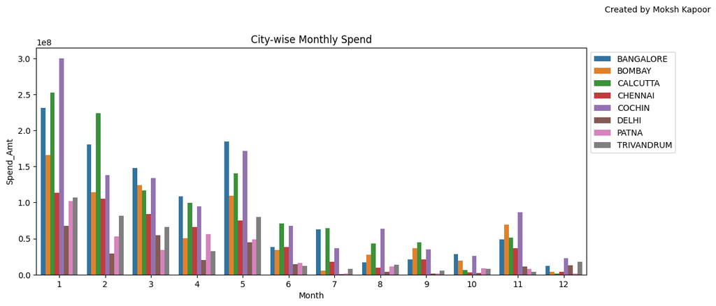

```python
plt.figure(figsize = (12,5))
sns.barplot(data=City_Monthly_spend,x="Month_spend",y="Amount_spend",hue= "City",estimator = sum)
plt.figtext(1,1,
    "Created by Moksh Kapoor",
    ha="center",
    fontsize=10
)
plt.title("City-wise Monthly Spend")
plt.xlabel("Month")
plt.ylabel("Spend_Amt")
plt.legend(bbox_to_anchor = (1,1), loc = "upper left")
plt.show()
```

**Insights**

2 A sudden drop in spending by customers can be seen after **June to September**,which may indicate seasonal changes, financial cycles, or customer behavior trends.

b. Comparison of yearly spend on air tickets

```python
yearly_airticket_spend = merged_data[merged_data["Type"]  == "AIR TICKET"].groupby(merged_data["Month_spend"].dt.year)["Amount_spend"].sum()
yearly_airticket_spend
```

```
Month_spend
2004   112682288.08
2005   287803078.76
2006   139632621.48
Name: Amount_spend, dtype: float64
```

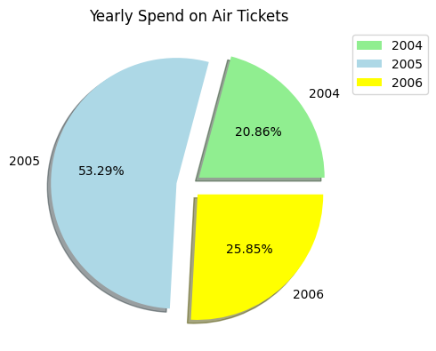

```python
plt.figure(figsize = (5,8))
plt.pie(yearly_airticket_spend,labels = yearly_airticket_spend.index,autopct = "%.2f%%",colors  = ["lightgreen","lightblue","yellow"],explode =(0.1,0.1,0.1),shadow =True)
plt.title("Yearly Spend on Air Tickets")
plt.legend(bbox_to_anchor = (1,1))
plt.tight_layout()
plt.show()
```

**Insights**

1 It is observed that Customers used the credit card for air ticket purchases higher in Year **2005**, followed by **2006** and **2004**.

3 There's an opportunity to create customized offers such as travel rewards, special airline partnerships, or promotional campaigns on credit cards targeting Platinum and Gold Customers

4 Opportunity to increase retention rate and increase profits by providing smoothless services and special seasonal offers.

c. Comparison of monthly spend for each product (look for any seasonality that exists in terms of spend)

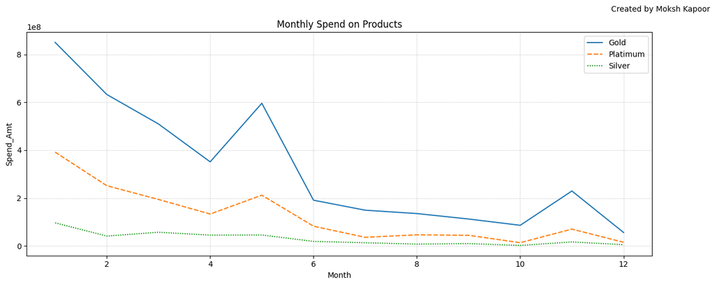

```python
monthly_product_spend = merged_data.groupby([merged_data["Month_spend"].dt.month,"Product"])["Amount_spend"].sum().reset_index()
monthly_product_spend

plt.figure(figsize = (12,5))
sns.lineplot(data=monthly_product_spend , x ="Month_spend" , y = "Amount_spend",hue="Product",style="Product")
plt.title("Monthly Spend on Products")
plt.legend(bbox_to_anchor = (1,1))
plt.xlabel("Month")
plt.figtext(1,1,
    "Created by Moksh Kapoor",
    ha="center",
    fontsize=10
)
plt.grid(True, which='both', linestyle='--', linewidth=0.5, alpha=0.7)
plt.ylabel("Spend_Amt")
plt.tight_layout()
plt.show()
```

**Insights**

1 **Gold** and **Platinum** Customers are making larger purchases or more frequent purchases in the middle months of the year (Jan to June), possibly related to seasonal promotions, summer sales, vacation purchases, or special events in these peak times.

2 End of the Year (October to December): - The **Silver** segment shows the least variation in spending over the months possibly due to customer behaviour changes, seasonal factors,political factors etc. Their spending appears fairly consistent suggesting a more budget-conscious segment.

3 There's an opportunity to create customized offers such as Cards cashbacks ,rewards points, or promotional campaigns on credit cards targeting **Platinum** and **Gold** Customers to increase retention rate and increase profits

4 For **Silver customers**, targeting them with end-of-year offers (October to December) might be a good strategy

```python
def top_10(product, Time):
    if Time == "yearly":

        filtered = merged_data[merged_data["Product"] == product].groupby([merged_data["Month_repayment"].dt.year,"City"])["Amount_repayment"].sum().reset_index()

        top_10 = filtered.rename(columns = {"Month_repayment":"Year"}).sort_values(by="Amount_repayment", ascending=False).head(10)
        return top_10

    elif Time == "monthly":
        filtered = merged_data[merged_data["Product"] == product].groupby([merged_data["Month_repayment"].dt.month_name(),"City"])["Amount_repayment"].sum().reset_index()

        top_10 = filtered.rename(columns = {"Month_repayment":"Month"}).sort_values(by="Amount_repayment", ascending=False).head(10)
        return top_10

    else:
        print("Time must be either 'yearly' or 'monthly'")
```

```python
top_10("Gold", "yearly")
```

|  | Year | City | Amount_repayment |
| --- | --- | --- | --- |
| 8 | 2005 | BANGALORE | 417508957.63 |
| 12 | 2005 | COCHIN | 359394757.73 |
| 16 | 2006 | BANGALORE | 354937664.82 |
| 18 | 2006 | CALCUTTA | 321517412.93 |
| 20 | 2006 | COCHIN | 300666945.49 |
| 0 | 2004 | BANGALORE | 288696829.25 |
| 10 | 2005 | CALCUTTA | 265451121.22 |
| 17 | 2006 | BOMBAY | 236219310.99 |
| 9 | 2005 | BOMBAY | 230017352.22 |
| 1 | 2004 | BOMBAY | 228581995.06 |

#### Overall Summary

3 The Adult age group is the highest spending demographic, making them a key target for personalized and premium offers.

5 Gold and Platinum customers show higher spend during Jan–June, likely due to seasonal sales, travel, or special events. Silver customers exhibit consistent behavior, with a slight uptick at the year-end (Oct–Dec), ideal for targeted festive or New Year offers.

6 Cities like Delhi and Patna show lower credit card usage

By see opportunity into seasonality,focusing on lower-performing cities, and promoted promotional campaigns, the bank can improve further growth and customer retention rate.